# Exploration of Red Wine Quality dataset

## by Dipesh Kumar Singh

## Understanding Dataset

This dataset is public available for research. The details are described in [Cortez et al., 2009]. The paper is available [here] http://repositorium.sdum.uminho.pt/bitstream/1822/10029/1/wine5.pdf

The inputs were subjected to objective tests and the output is based on sensory analysis (median of at least 3 evaluations made by wine experts). Each expert graded the wine quality between 0 (very bad) and 10 (very excellent).

There are many factors which contributes to taste and quality of wine. In this exercise I will examine 11 variables on the properties of wine. This data set contains 1,599 red wines with 11 variables on the chemical properties of the wine.

### Input variables (based on physicochemical tests):

- 1 - fixed acidity (tartaric acid - g / dm<sup>3)</sup>
- 2 - volatile acidity (acetic acid - g / dm<sup>3)</sup>
- 3 - citric acid (g / dm<sup>3)</sup>
- 4 - residual sugar (g / dm<sup>3)</sup>
- 5 - chlorides (sodium chloride - g / dm<sup>3</sup>
- 6 - free sulfur dioxide (mg / dm<sup>3)</sup>
- 7 - total sulfur dioxide (mg / dm<sup>3)</sup>
- 8 - density (g / cm<sup>3)</sup>
- 9 - pH
- 10 - sulphates (potassium sulphate - g / dm3)
- 11 - alcohol (% by volume)

### Description of Variables

1 - fixed acidity: Acids are major wine constituents that is fixed or nonvolatile.

2 - volatile acidity: The amount of Acetic acid in wine, which at too high of levels can lead to an unpleasant, like reminiscent of vinegar, rotten-apples.

3 - citric acid: found in small quantities, citric acid can add 'freshness' and flavor to wines and will effectively make a wine more acidic.

4 - residual sugar: Any natural grape sugars that are leftover after fermentation ceases, it's rare to find wines with less than 1 g/liter and wines with greater than 45 g/liter are considered sweet

5 - chlorides: the amount of salt in the wine

6 - free sulfur dioxide: The free form of SO2 exists in equilibrium between molecular SO2 (as a dissolved gas) and bisulfite ion; it prevents microbial growth and the oxidation of wine

7 - total sulfur dioxide: amount of free and bound forms of S02; in low concentrations, SO2 is mostly undetectable in wine, but at free SO2 concentrations over 50 ppm, SO2 becomes evident in the nose and taste of wine

8 - density: the density of water is close to that of water depending on the percent alcohol and sugar content

9 - pH: describes how acidic or basic a wine is on a scale from 0 (very acidic) to 14 (very basic); most wines are between 3-4 on the pH scale

10 - sulphates: a wine additive which can contribute to sulfur dioxide gas (S02) levels, wich acts as an antimicrobial and antioxidant

11 - alcohol: the percent alcohol content of the wine

Output variable (based on sensory data): 12 - quality (score between 0 and 10)

In this project i will try to explore physicochemical input variables, identify correlation, detect outliers and discover interesting relationship in this data to identify chemical properties that influence the quality of red wines.

## Initial Exploration

Let's run some commands to learn structure and schema of the dataset.

```
##   X fixed.acidity volatile.acidity citric.acid residual.sugar chlorides
## 1 1           7.4             0.70        0.00            1.9     0.076
## 2 2           7.8             0.88        0.00            2.6     0.098
## 3 3           7.8             0.76        0.04            2.3     0.092
## 4 4          11.2             0.28        0.56            1.9     0.075
## 5 5           7.4             0.70        0.00            1.9     0.076
## 6 6           7.4             0.66        0.00            1.8     0.075
##   free.sulfur.dioxide total.sulfur.dioxide density   pH sulphates alcohol
## 1                  11                   34  0.9978 3.51      0.56     9.4
## 2                  25                   67  0.9968 3.20      0.68     9.8
## 3                  15                   54  0.9970 3.26      0.65     9.8
## 4                  17                   60  0.9980 3.16      0.58     9.8
## 5                  11                   34  0.9978 3.51      0.56     9.4
## 6                  13                   40  0.9978 3.51      0.56     9.4
##   quality
## 1       5
## 2       5
## 3       5
## 4       6
## 5       5
## 6       5
```

```
##         X fixed.acidity volatile.acidity citric.acid residual.sugar
## 1594 1594           6.8            0.620        0.08            1.9
## 1595 1595           6.2            0.600        0.08            2.0
## 1596 1596           5.9            0.550        0.10            2.2
## 1597 1597           6.3            0.510        0.13            2.3
## 1598 1598           5.9            0.645        0.12            2.0
## 1599 1599           6.0            0.310        0.47            3.6
##      chlorides free.sulfur.dioxide total.sulfur.dioxide density   pH
## 1594     0.068                  28                   38 0.99651 3.42
## 1595     0.090                  32                   44 0.99490 3.45
## 1596     0.062                  39                   51 0.99512 3.52
## 1597     0.076                  29                   40 0.99574 3.42
## 1598     0.075                  32                   44 0.99547 3.57
## 1599     0.067                  18                   42 0.99549 3.39
##      sulphates alcohol quality
## 1594      0.82     9.5       6
## 1595      0.58    10.5       5
## 1596      0.76    11.2       6
## 1597      0.75    11.0       6
## 1598      0.71    10.2       5
## 1599      0.66    11.0       6
```

```
## [1] 1599   13
```

```
## 'data.frame':    1599 obs. of  13 variables:
##  $ X                   : int  1 2 3 4 5 6 7 8 9 10 ...
##  $ fixed.acidity       : num  7.4 7.8 7.8 11.2 7.4 7.4 7.9 7.3 7.8 7.5 ...
##  $ volatile.acidity    : num  0.7 0.88 0.76 0.28 0.7 0.66 0.6 0.65 0.58 0.5 ...
##  $ citric.acid         : num  0 0 0.04 0.56 0 0 0.06 0 0.02 0.36 ...
##  $ residual.sugar      : num  1.9 2.6 2.3 1.9 1.9 1.8 1.6 1.2 2 6.1 ...
##  $ chlorides           : num  0.076 0.098 0.092 0.075 0.076 0.075 0.069 0.065 0.073 0.071 ...
##  $ free.sulfur.dioxide : num  11 25 15 17 11 13 15 15 9 17 ...
##  $ total.sulfur.dioxide: num  34 67 54 60 34 40 59 21 18 102 ...
##  $ density             : num  0.998 0.997 0.997 0.998 0.998 ...
##  $ pH                  : num  3.51 3.2 3.26 3.16 3.51 3.51 3.3 3.39 3.36 3.35 ...
##  $ sulphates           : num  0.56 0.68 0.65 0.58 0.56 0.56 0.46 0.47 0.57 0.8 ...
##  $ alcohol             : num  9.4 9.8 9.8 9.8 9.4 9.4 9.4 10 9.5 10.5 ...
##  $ quality             : int  5 5 5 6 5 5 5 7 7 5 ...
```

```
##        X          fixed.acidity   volatile.acidity  citric.acid
##  Min.   :   1.0   Min.   : 4.60   Min.   :0.1200   Min.   :0.000
##  1st Qu.: 400.5   1st Qu.: 7.10   1st Qu.:0.3900   1st Qu.:0.090
##  Median : 800.0   Median : 7.90   Median :0.5200   Median :0.260
##  Mean   : 800.0   Mean   : 8.32   Mean   :0.5278   Mean   :0.271
##  3rd Qu.:1199.5   3rd Qu.: 9.20   3rd Qu.:0.6400   3rd Qu.:0.420
##  Max.   :1599.0   Max.   :15.90   Max.   :1.5800   Max.   :1.000
##  residual.sugar     chlorides       free.sulfur.dioxide
##  Min.   : 0.900   Min.   :0.01200   Min.   : 1.00
##  1st Qu.: 1.900   1st Qu.:0.07000   1st Qu.: 7.00
##  Median : 2.200   Median :0.07900   Median :14.00
##  Mean   : 2.539   Mean   :0.08747   Mean   :15.87
##  3rd Qu.: 2.600   3rd Qu.:0.09000   3rd Qu.:21.00
##  Max.   :15.500   Max.   :0.61100   Max.   :72.00
##  total.sulfur.dioxide    density             pH          sulphates
##  Min.   :  6.00       Min.   :0.9901   Min.   :2.740   Min.   :0.3300
##  1st Qu.: 22.00       1st Qu.:0.9956   1st Qu.:3.210   1st Qu.:0.5500
##  Median : 38.00       Median :0.9968   Median :3.310   Median :0.6200
##  Mean   : 46.47       Mean   :0.9967   Mean   :3.311   Mean   :0.6581
##  3rd Qu.: 62.00       3rd Qu.:0.9978   3rd Qu.:3.400   3rd Qu.:0.7300
##  Max.   :289.00       Max.   :1.0037   Max.   :4.010   Max.   :2.0000
##     alcohol         quality
##  Min.   : 8.40   Min.   :3.000
##  1st Qu.: 9.50   1st Qu.:5.000
##  Median :10.20   Median :6.000
##  Mean   :10.42   Mean   :5.636
##  3rd Qu.:11.10   3rd Qu.:6.000
##  Max.   :14.90   Max.   :8.000
```

```
##    Min. 1st Qu.  Median    Mean 3rd Qu.    Max.
##   3.000   5.000   6.000   5.636   6.000   8.000
```

```r
dataf$quality <- factor(dataf$quality, ordered = T)
str(dataf$quality)
```

```
##  Ord.factor w/ 6 levels "3"<"4"<"5"<"6"<..: 3 3 3 4 3 3 3 5 5 3 ...
```

# Univariate Plots Section

Let's analyze the distribution of values of all the 12 variables including quality.

[output not shown]

```
## stat_bin: binwidth defaulted to range/30. Use 'binwidth = x' to adjust this.
## stat_bin: binwidth defaulted to range/30. Use 'binwidth = x' to adjust this.
## stat_bin: binwidth defaulted to range/30. Use 'binwidth = x' to adjust this.
```

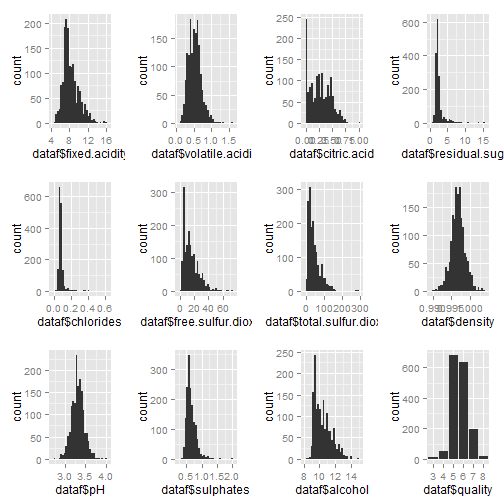

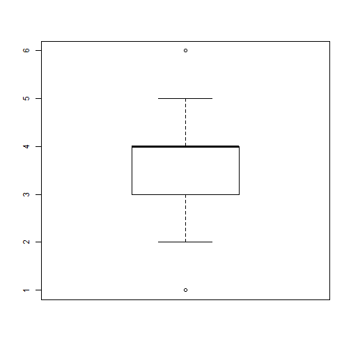

```r
boxplot(dataf[,13])
```

# Univariate Analysis

### Wine Quality

Although it has a descrete range of only 3-8, It is slightly evident that there is some amount of normal distribution. Mostly wines examined received ratings of 5 or 6, and very received 3, 4 or 8.

Let's observe if another categorical variable is introduced, which classifies as 'bad' (rating 0 to 4), 'average' (rating 5 or 6), and 'good' (rating 7 to 10).

```
##     bad average    good
##      63    1319     217
```

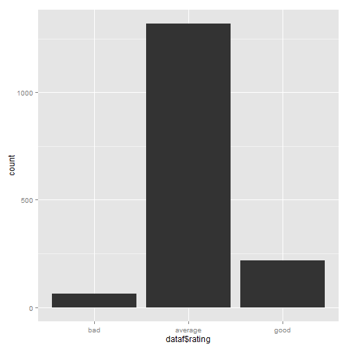

### Distributions and Outliers

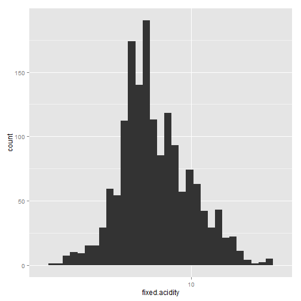

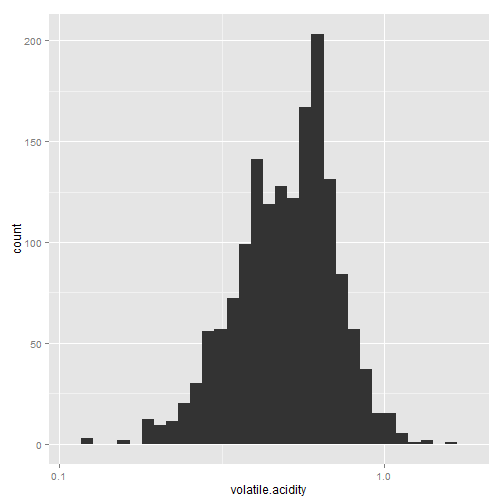

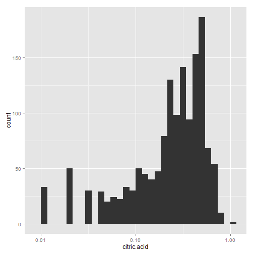

When plotted on a base 10 logarithmic scale, `fixed.acidity` and `volatile.acidity` follows normal distribution (at least it is more like bell-shaped in logorithmic than regular); This makes sense, considering that `pH` is normally distributed, and pH by definition is a measure of acidity on a logarithmic scale. Curiously, however, `citric.acid`, did not appear to be normally-distributed on a logarithmic scale. Upon further investigation:

```r
length(subset(dataf, citric.acid == 0)$citric.acid)
```

```
## [1] 132
```

It seems like 132 observations had a value of zero, which might be the case of missing or unreported values.

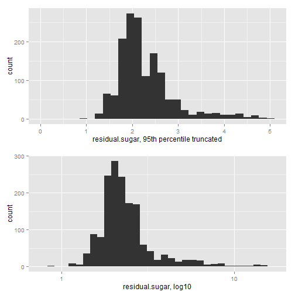

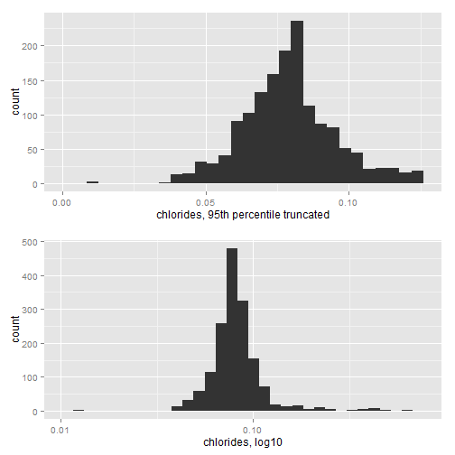

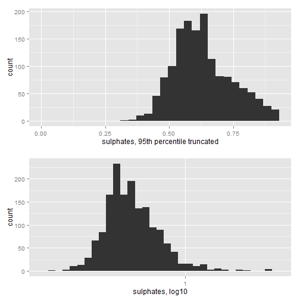

I will add one more variable 'total.acidity' to combine the affect of acidity.

```
## stat_bin: binwidth defaulted to range/30. Use 'binwidth = x' to adjust this.
```

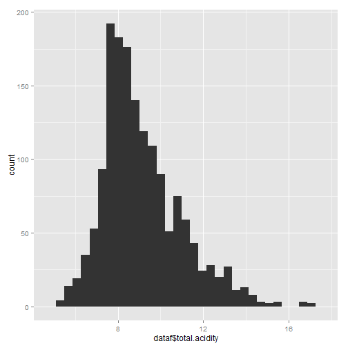

Boxplots are better suited in visualizing the outliers.

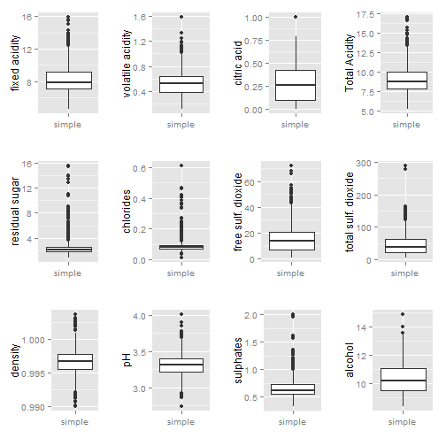

Bivariate box plots with X as quality will be more interesting in showing trends with Wine quality.

# Bivariate Plots Section

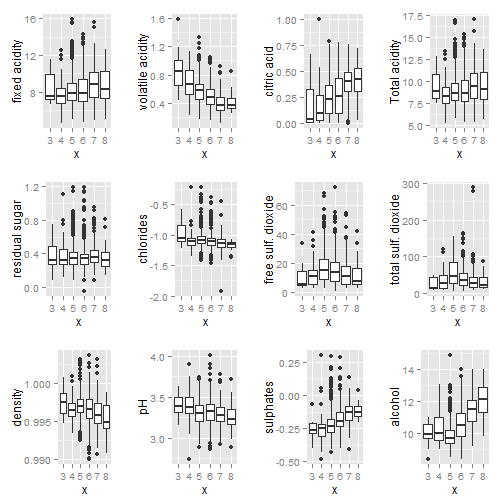

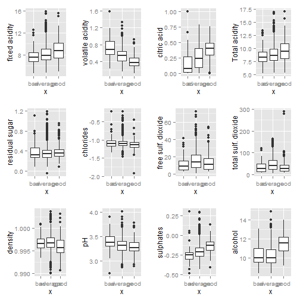

[output not shown]

## fixed.acidity volatile.acidity citric.acid

## 0.12405165 -0.39055778 0.22637251

## total.acidity log10.residual.sugar log10.chlordies

## 0.10375373 0.02353331 -0.17613996

## free.sulfur.dioxide total.sulfur.dioxide density

## -0.05065606 -0.18510029 -0.17491923

## pH log10.sulphates alcohol

## -0.05773139 0.30864193 0.47616632

[output not shown]

## Pearson's product-moment correlation

## data: dataf$fixed.acidity and dataf$citric.acid

## t = 36.2341, df = 1597, p-value < 2.2e-16

## alternative hypothesis: true correlation is not equal to 0

## 95 percent confidence interval:

## 0.6438839 0.6977493

## sample estimates:

## cor

## 0.6717034

[output not shown]

## Pearson's product-moment correlation

## data: dataf$volatile.acidity and dataf$citric.acid

## t = -26.4891, df = 1597, p-value < 2.2e-16

## alternative hypothesis: true correlation is not equal to 0

## 95 percent confidence interval:

## -0.5856550 -0.5174902

## sample estimates:

## cor

## -0.5524957

[output not shown]

## Pearson's product-moment correlation

## data: log10(dataf$total.acidity) and dataf$pH

## t = -39.6631, df = 1597, p-value < 2.2e-16

## alternative hypothesis: true correlation is not equal to 0

## 95 percent confidence interval:

## -0.7283140 -0.6788653

## sample estimates:

## cor

## -0.7044435

```
Yes, base 10 logarithm `total.acidity` correlated well with pH. This is expected because pH is measure of acidity.
```

## geom_smooth: method=“auto” and size of largest group is >=1000, so using gam with formula: y ~ s(x, bs = “cs”). Use 'method = x' to change the smoothing method.

[output not shown]

## Pearson's product-moment correlation

## data: dataf$free.sulfur.dioxide and dataf$total.sulfur.dioxide

## t = 35.8402, df = 1597, p-value < 2.2e-16

## alternative hypothesis: true correlation is not equal to 0

## 95 percent confidence interval:

## 0.6395786 0.6939740

## sample estimates:

## cor

## 0.6676665

[output not shown]